# Covid Art Auctions

Author

Tuesday Group 8

# Did Covid Impact the Contemporary Art Auction Market? Final Project by Isabelle Zhang

## 1. Introduction

Commencing in late 2019, the COVID-19 pandemic significantly influenced the art industry, causing extensive disruptions attributable to global lockdowns and restrictions. This study concentrates on Christie’s, a renowned auction house, and specifically examines its contemporary art auctions held between 2018 and 2023. The objective is **to investigate the impact of the pandemic on Christie’s, considering both the immediate consequences during the peak of the pandemic and the subsequent period post-pandemic, with a focus on their New York and Hong Kong branches.**

I collected the data with the help of my friends Eduardo Penaranda, Cynthia Wang, Jane Yoon from Christie’s official website (https://www.christies.com/). We manually collected information of each contemporary art auction in Christie’s New York and Hong Kong, including auction names, dates, total sales figures, number of lots, auction formats, and the classification of day or evening auctions.

To ensure uniformity and comparability, I converted all financial figures from Hong Kong Dollars (HKD) to United States Dollars (USD) using an exchange rate of 1:0.13. I also **defined Covid Status differently** for New York and Hong Kong, as the specific covid conditions and restrictions differ significantly. In Hong Kong, the pre-COVID period spans from January 2018 to January 2020, the COVID period ranges from February 2020 (first Covid case in Hong Kong) to September 2022 (when Hong Kong lifted travel restrictions and lockdown policies), and the post-COVID period extends from October 2022 to November 2023 (present). In New York, the pre-COVID period covers January 2018 to February 2020, the COVID period spans from March 2020 (first Covid case in New York) to June 2021, and the post-COVID period is from July 1, 2021 (when New York fully reopened), to November 2023 (current).

```
Rows: 281
Columns: 10
$ Auction_Name    <chr> "First Open | Post-War & Contemporary Art", "Design", …
$ Auction_Year    <int> 2022, 2022, 2022, 2022, 2022, 2022, 2022, 2022, 2022, …
$ Auction_Date    <chr> "2022.12.1-14", "2022.12.9", "2022.12.9", "2022.12.7",…
$ Auction_Month   <int> 12, 12, 12, 12, 11, 11, 11, 11, 11, 11, 10, 10, 9, 9, …
$ Sales_Total_USD <dbl> 6967346, 8474130, 6701400, 77043008, 1458828, 78025524…
$ Lots_Number     <int> 275, 150, 12, 157, 77, 261, 69, 35, 95, 60, 160, 131, …
$ Auction_Format  <chr> "online", "live", "live", "live", "online", "live", "l…
$ Auction_Time    <chr> "day", "day", "day", "day", "day", "day", "evening", "…
$ Mean_Price_USD  <dbl> 2.533580e+04, 5.649420e+04, 5.584500e+05, 4.907198e+05…
$ source          <chr> "NY", "NY", "NY", "NY", "NY", "NY", "NY", "NY", "NY", …
```

## 2. Exploratory Analysis

### 2.1 Distribution of Total Sales Across Covid Status

Below (figure 1) is a jitter plot of the distribution of total sales across different covid status, grouped by whether the source is New York or Hong Kong. From an overlook, we can see the **overall distribution is similar between different covid periods within each location**, but I also want to see in more detail how covid influenced the art market, which I will do in following sections.

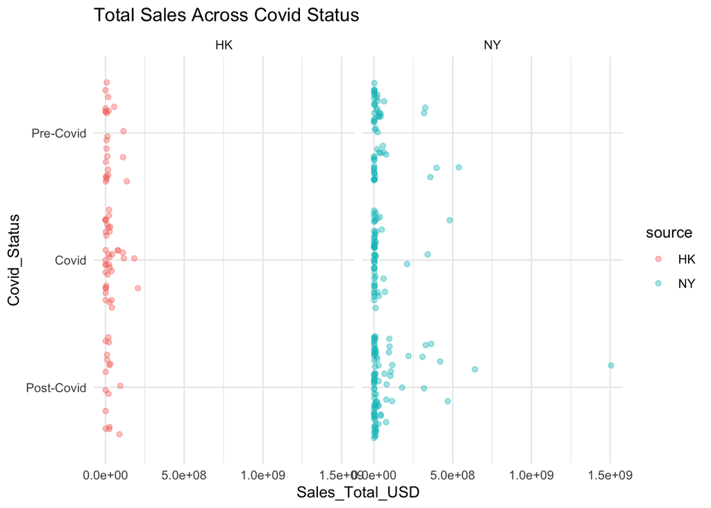

Figure 1: Colored jitterplot of the distribution of total sales across different covid status, grouped by source New York and Hong Kong

### 2.2 Aggregated Total Sales In Covid Status

Figure 2 shows the aggregated total sales of each auction within the covid status, grouped by source New York and Hong Kong. This figure shows that the aggregated total sales for New York dropped during covid but then rised significantly (even much higher than pre covid) post covid. For Hong Kong, the aggregated total sales rised a bit during covid, but fell after covid (even lower than pre covid).

This figure visualizes the trend of aggregated total sales across different status, but can be an oversimplification of the relationship. In the next part, I will conduct a more detailed analysis through regression, could provide a more nuanced understanding.

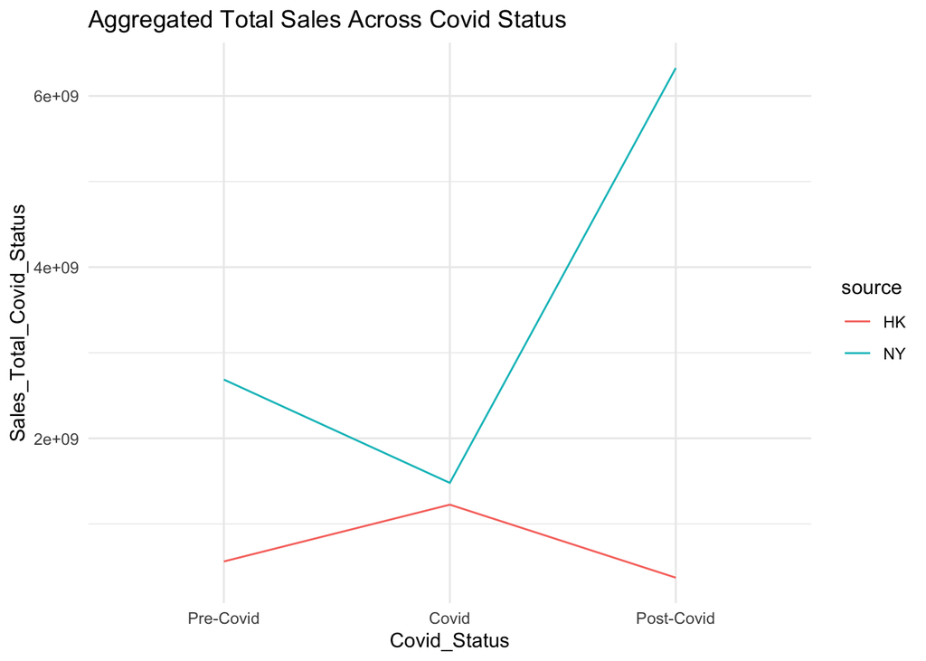

Figure 2: Colored linegraph of how the aggregated total sales of changed across different covid status, grouped by source New York and Hong Kong.

## 3. Comparing Regression Models

I employed three models to measure the effect of Covid Status on Sales Total in different sources (New York or Hong Kong), all are linear regressions with the dependent variable Sales_Total_USD.

- **mod1:** only takes into account the linear relationship between Sales_Total_USD and the variables source and Auction_Time, assuming no interaction with the Covid_Status variable.
- **mod 2:** extends mod1 by including the Covid_Status variable. It measures the linear relationship between Sales_Total_USD and the variables Covid_Status, source, and Auction_Time, assuming that Covid_Status affected source New York and Hong Kong the same.
- **mod 3:** further includes an interaction term between Covid_Status and source, assuming Covid_Status affected New York and Hong Kong differently.

Below are the AIC results for each model, mod1 has the lowest AIC of 11201.93, and is therefore the best model for predicting Sales_Total_USD. Because this is the model that didn’t consider Covid Status’s effect on Sales Total, we can draw the conclusion that **Covid has very little impact on the art market.**

```
     df      AIC
mod1  4 11201.93
mod2  6 11204.97
mod3  8 11205.88
```

Table 1: The AIC results of mod1, 2, and 3

## 4. Detailed Models

### 4.1 Mod1

To further see the predicted results of the best model mod1, I tidied the model (table2) and plotted the predicted results (figure 3). Table 2 shows that

- The estimate for a day sale in Hong Kong is -9780446 USD
- The estimate for a day sale in New York is -9780446 + 41743920 *1= 31963474 USD
- The estimate for a evening sale in Hong Kong is -9780446 + 207313038 *1 = 197532592 USD
- The estimate for a evening sale in New York is -9780446 + 41743920 *1+ 207313038 *1 = 239276512 USD

Figure 3 shows that the predicted values for sales total in New York is between around 1.3e +7 and 4.8e + 7, and the predicted values for sales total in Hong Kong is between -3.75+7 and 1.3e +7. The predicted sales total in New York is much higher than in Hong Kong.

```
# A tibble: 3 × 5
  term                  estimate std.error statistic  p.value
  <chr>                    <dbl>     <dbl>     <dbl>    <dbl>
1 (Intercept)          -9780446. 13022207.    -0.751 4.53e- 1
2 sourceNY             41743920. 14721150.     2.84  4.91e- 3
3 Auction_Timeevening 207313038. 20311531.    10.2   5.56e-21
```

Table 2: The regression results for mod1

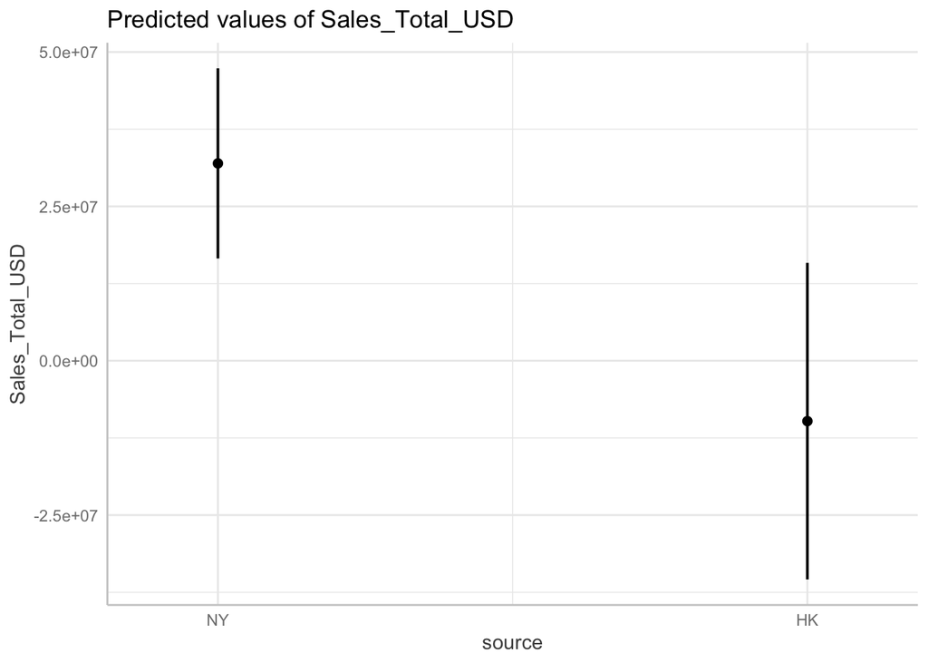

Figure3: mod1 regression predicted results for sales total in the two sources

### 4.1.5 Residuals Analysis for Mod1

I conducted residual analysis for Mod1 to further assess the performance of this linear regression model and see if it can be trusted. I used Normal Q-Q Plot (figure 4).

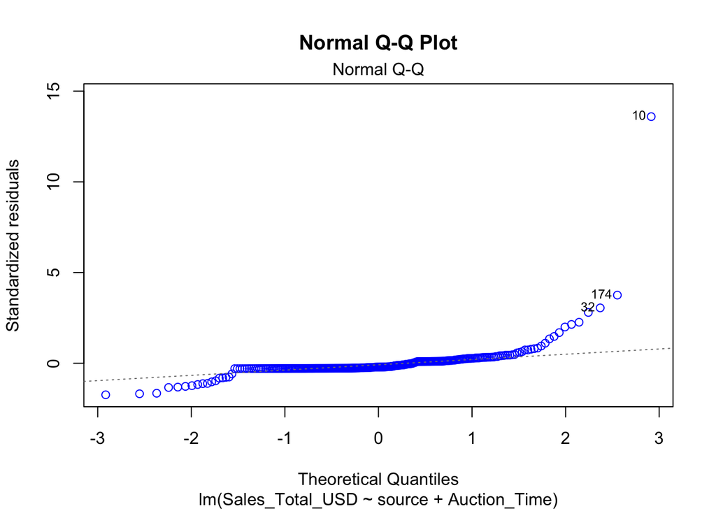

Figure 4: Residual Plot for mod 1- Normal Q-Q Plot

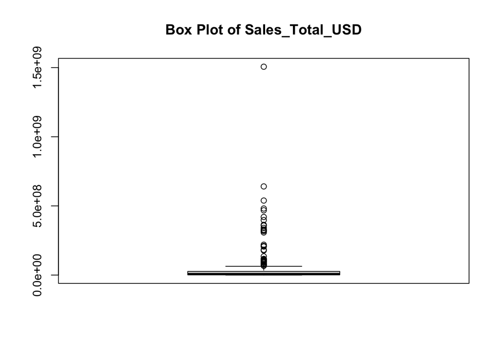

Figure 5: Box plot for the distribution of total sales

```
# A tibble: 15 × 4
# Groups:   source, Covid_Status [3]
   Auction_Name                              source Sales_Total_USD Covid_Status
   <chr>                                     <chr>            <dbl> <fct>
 1 Visionary: The Paul G. Allen Collection … NY          1506386000 Post-Covid
 2 20th Century Evening Sale                 NY           640846000 Post-Covid
 3 Post-War and Contemporary Art Evening Sa… NY           538721750 Pre-Covid
 4 20th Century Evening Sale                 NY           481114000 Covid
 5 20th Century Evening Sale                 NY           468174000 Post-Covid
 6 20th Century Evening Sale                 NY           419866500 Post-Covid
 7 Post-War and Contemporary Art Evening Sa… NY           397159500 Pre-Covid
 8 The Collection of Anne H. Bass            NY           363087500 Post-Covid
 9 Post-War and Contemporary Art Evening Sa… NY           357622500 Pre-Covid
10 20th Century Evening Sale                 NY           340851500 Covid
11 20th Century Evening Sale                 NY           328779600 Post-Covid
12 Post-War and Contemporary Art Evening Sa… NY           325259750 Pre-Covid
13 The Collection of Thomas and Doris Amman… NY           317806490 Post-Covid
14 An American Place | The Barney A. Ebswor… NY           317801250 Pre-Covid
15 20th Century Evening Sale                 NY           307945300 Post-Covid
```

Table 3: The 15 highest selling auctions

### 4.2 Mod 2 & mod 3

Although mod2 and mod3 are not the best model in this case, I still plotted them to see their relative results. These results show the relative trends predicted in each model, but since they are not the best models and that the model without considering covid’s impact is the best model, mod2 and mod3 ’s results will not be taken into consideration for the final result.

- Figure 5 assumes that covid impacted New York and Hong Kong the same. It shows that there is a very small rise in total sales during covid, and then a slightly more significant rise post covid.
- Figure 6 assumes that covid impacted New York and Hong Kong differently, it shows that for New York, the sales total decreased during covid and then increased again after covid (to a point higher than pre-covid). For Hong Kong, sales total increased a bit during covid, but decreased after covid (to a point lower than pre-covid).

```
# A tibble: 5 × 5
  term                     estimate std.error statistic  p.value
  <chr>                       <dbl>     <dbl>     <dbl>    <dbl>
1 (Intercept)            -12930133. 16728258.   -0.773  4.40e- 1
2 Covid_StatusCovid        1080372. 16677600.    0.0648 9.48e- 1
3 Covid_StatusPost-Covid  13861885. 16185486.    0.856  3.92e- 1
4 sourceNY                38593367. 15222479.    2.54   1.18e- 2
5 Auction_Timeevening    205713913. 20462643.   10.1    1.83e-20
```

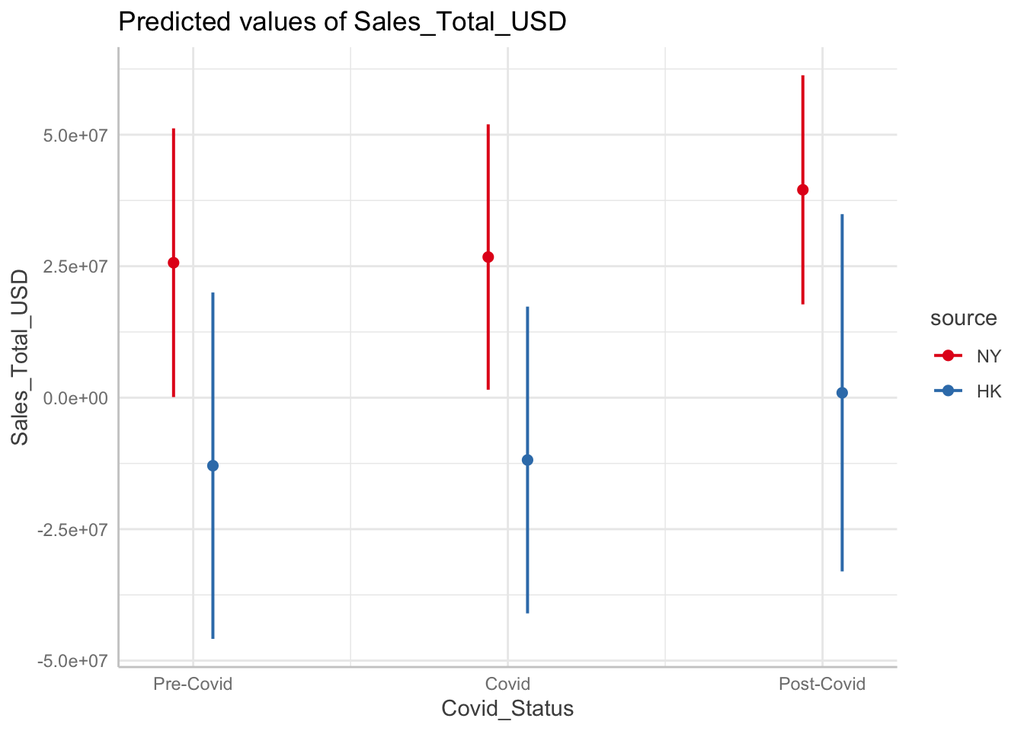

Figure 5: mod2 regression predicted results for sales total in the two sources, taking into account the covid influence.

```
# A tibble: 7 × 5
  term                              estimate std.error statistic  p.value
  <chr>                                <dbl>     <dbl>     <dbl>    <dbl>
1 (Intercept)                     -20536020. 23105547.    -0.889 3.75e- 1
2 Covid_StatusCovid                25711269. 28923187.     0.889 3.75e- 1
3 Covid_StatusPost-Covid           -7913571. 35406739.    -0.224 8.23e- 1
4 sourceNY                         49029279. 26929475.     1.82  6.98e- 2
5 Auction_Timeevening             206793305. 20435490.    10.1   1.17e-20
6 Covid_StatusCovid:sourceNY      -38863790. 35352418.    -1.10  2.73e- 1
7 Covid_StatusPost-Covid:sourceNY  23933459. 39837411.     0.601 5.48e- 1
```

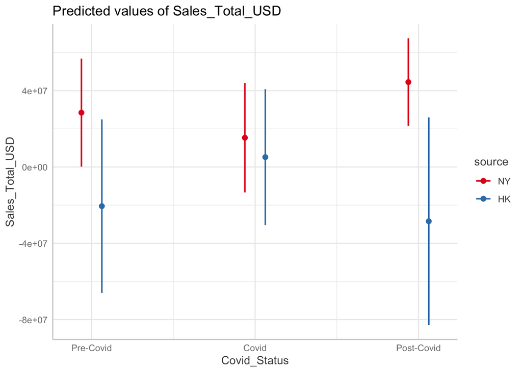

Figure 6: mod3 regression predicted results for sales total in the two sources, with interactive variables of covid status * source

## 5.Conclusion

**Covid had little impact on the sales total in Christie’s New York and Hong Kong.**

This analysis employing three linear regression models aimed to measure the impact of Covid Status on Sales Total in different sources, specifically New York and Hong Kong. While each model varied in its inclusion of Covid_Status and interaction terms, the model with the lowest AIC was mod1, which did not consider the effect of Covid_Status on Sales Total. The AIC results, with mod1 having the lowest value at 11201.93, suggest that incorporating Covid_Status did not significantly improve the predictive power of the models.

Based on the analysis and model comparisons, it appears that Covid-19 had a limited impact on the art auction market, at least in the context of the variables considered in the study. The predictive power of the model that excluded the Covid_Status variable (mod1) suggests that factors other than the pandemic may have played a more substantial role in influencing Sales_Total_USD. It is essential to consider additional factors and conduct further research to gain a comprehensive understanding of the nuanced dynamics affecting the art market during and after the pandemic.

## 6.Citations

Christie’s. “Christie’s: Fine Art, Luxury & Antiques: Auctions & Private Sales.” Christie’s | Fine Art, Luxury & Antiques | Auctions & Private Sales, n.d. https://www.christies.com/.